# Chapter 9 - Prediction and Bayesian inference

- Bayesian inference involves 3 steps that go beyond classical estimation:
1. the data and model are combined to form a posterior distribution
2. we get uncertainty in this distribution - simulation based predictions for unobserved or future outcomes that accounts for uncertainty in the model parameters
3. we can include additional information into the model using a prior distribution

# Propagating uncertainty in the inference using posterior simulations

```r
print(fit.1)
```

```
stan_glm
 family:       gaussian [identity]
 formula:      vote ~ growth
 observations: 16
 predictors:   2
------
            Median MAD_SD
(Intercept) 46.2    1.7
growth       3.1    0.7

Auxiliary parameter(s):
      Median MAD_SD
sigma 3.9    0.7

------
* For help interpreting the printed output see ?print.stanreg
* For info on the priors used see ?prior_summary.stanreg
```

- these numbers are summaries of a matrix of simulations representing different possible values of the parameter vector $(a, b, \sigma)$. We get a set of posterior simulation rather than a single point estimate because we have uncertainty about these parameters
- we can access the simulations by extracting the fitted model as a matrix:

| (Intercept) | growth | sigma |
| --- | --- | --- |
| 46.234230 | 3.0609780 | 3.8877186 |
| 1.671274 | 0.7438517 | 0.7268588 |

## Uncertainty in the regression coefficients and implied uncertainty in the regression line

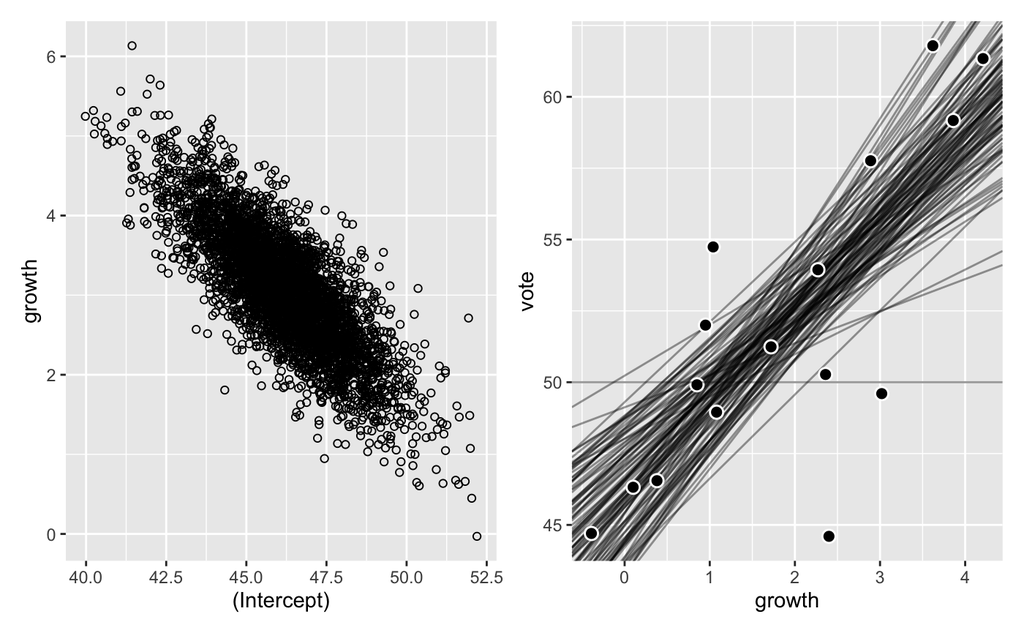

## Using the matrix of posterior simulations to express uncertainty about a parameter estimate or function of parameter estimates

- suppose we wanted a standard error for a combination of parameters like $a / b$:

```r
print(c(median(z), mad(z)))
```

```
[1] 15.082213  4.012321
```

# Prediction and uncertainty: `predict`, `posterior_linpred`, and `posterior_predict`

After fitting a regression we can use the model to predict a new data point, or a set of new points. We can make three sorts of predictions:

1. the point prediction: based on the fitted model, this is the best point estimate of the average value for new data points with the new value of x
2. the linear predictor with uncertainty: the represents the distribution of uncertainty about the expected or average value of $y$ for new data points with predictors
3. the predictive distribution for a new observation: this represents uncertainty about a new observation $y$ with predictions

## Point prediction using `predict`

We will predict the incumbent’s vote share, conditional on economic growth of 2%

```r
head(y.point.pred)
```

```
       1
52.32204
```

## Linear predictor with uncertainty using `posterior_linpred` or `posterior_epred`

- we use `posterior_linpred` to get uncertainty in the value of the fitted regression line. This will return a vector of posterior simulations from a distribution whose mean equals the point prediction obtained above and whose standard deviation represents uncertainty in the fitted model:

```r
head(y.linpred)
```

```
iterations        1
      [1,] 52.65596
      [2,] 52.70712
      [3,] 51.40522
      [4,] 53.58537
      [5,] 51.51470
      [6,] 52.07256
```

## Predictive distribution for a new observation using `posterior_predict`

```r
cat("Predicted Clinton percentage of 2-party vote:", round(y.pred.median,1),
    ", with s.e.", round(y.pred.mad, 1), "\nPr (Clinton win) =",
    round(win_prob, 2), sep = " ")
```

```
Predicted Clinton percentage of 2-party vote: 52.4 , with s.e. 3.8
Pr (Clinton win) = 0.74
```

## Prediction given a range of input values

We can also use these functions to generate a range of predicted values, for example predicting the election outcome for a grid of possible values of economic growth from -2% to +4%

```r
new.grid <- tibble(
  growth = seq(from = -2.0, to = 4.0, by = 0.5)
)
y.point.pred.grid <- predict(fit.1, newdata = new.grid)
y.linpred.grid <- posterior_linpred(fit.1, newdata = new.grid)
y.pred.grid <- posterior_predict(fit.1, newdata = new.grid)
```

## Propagating uncertainty

- our predictor of economic growth also has some uncertainty

```r
y.pred.median <- median(y.pred)
y.pred.mad <- mad(y.pred)
win_prob <- mean(y.pred > 50)
cat("Predicted Clinton percentage of 2-party vote:", round(y.pred.median,1),
    ", with s.e.", round(y.pred.mad, 1), "\nPr (Clinton win) =",
    round(win_prob, 2), sep = " ")
```

```
Predicted Clinton percentage of 2-party vote: 52.4 , with s.e. 4.1
Pr (Clinton win) = 0.71
```

## Simulating uncertainty for the linear predictor and new observation

```r
print(fit.1)
```

```
stan_glm
 family:       gaussian [identity]
 formula:      weight ~ height
 observations: 1789
 predictors:   2
------
            Median MAD_SD
(Intercept) -173.3   12.1
height         4.9    0.2

Auxiliary parameter(s):
      Median MAD_SD
sigma 29.0    0.5

------
* For help interpreting the printed output see ?print.stanreg
* For info on the priors used see ?prior_summary.stanreg
```

The intercept is difficult to interpret, so we center height:

```r
print(fit.2)
```

```
stan_glm
 family:       gaussian [identity]
 formula:      weight ~ c_height
 observations: 1789
 predictors:   2
------
            Median MAD_SD
(Intercept) 156.2    0.6
c_height      5.0    0.2

Auxiliary parameter(s):
      Median MAD_SD
sigma 29.0    0.5

------
* For help interpreting the printed output see ?print.stanreg
* For info on the priors used see ?prior_summary.stanreg
```

```r
# posterior predictive simulations for a single new person of height 70 inches
y.postpred2 <- posterior_predictfit.2, (newdata = new)
```

```
Error: unexpected ',' in "y.postpred2 <- posterior_predictfit.2,"
```

# Example of Bayesian inference: beauty and sex ratio

A study found that parents in higher attractiveness categories had more girls

## Prior information

- human sex ratio occurs in a very narrow range. 48.7% girls among whites, 49.2% among blacks
- similar differences of half of a percentage point or less have been found when comparing based on factors such as birth order, maternal age, or season of birth. given that attractiveness is itself only subjectively measured, we find it hard to believe that any difference between more and less attractive parents could be as large as 0.5%

# Uniform, weakly informative, and informative priors in regression

## Uniform prior distribution

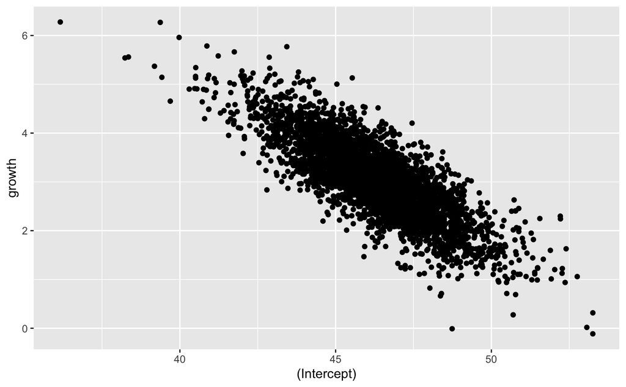

## Default prior distribution

```r
fit.1 <- stan_glm(vote ~ growth, data = hibbs)

# or
sd_x <- sd(hibbs$growth)
sd_y <- sd(hibbs$vote)
mean_y <- mean(hibbs$vote)

fit.1a <- stan_glm(vote ~ growth, data = hibbs,
                   prior = normal(0, 2.5 * sd_y / sd_x),
                   prior_intercept = normal(mean_y, 2.5 * sd_y),
                   prior_aux = exponential(1 / sd_y))
```

## Weakly informative prior distribution based on subject-matter knowledge

- for a model of vote share, we might use a prior of 50 with sd of 10 for the intercept
- considering that economic growth typically ranges between 0-4% we might use a prior mean of 5 with standard deviation of 5 to tell the model that the values will probably be positive and probably not be greater than 10

```r
print(fit.4)
```

```
stan_glm
 family:       gaussian [identity]
 formula:      vote ~ growth
 observations: 16
 predictors:   2
------
            Median MAD_SD
(Intercept) 46.2    1.6
growth       3.1    0.7

Auxiliary parameter(s):
      Median MAD_SD
sigma 3.9    0.7

------
* For help interpreting the printed output see ?print.stanreg
* For info on the priors used see ?prior_summary.stanreg
```

## Example where an informative prior makes a difference: Beauty and sex ratio

```r
print(fit.5b)
```

```
stan_glm
 family:       gaussian [identity]
 formula:      y ~ x
 observations: 5
 predictors:   2
------
            Median MAD_SD
(Intercept) 49.0    1.4
x            0.2    0.5

Auxiliary parameter(s):
      Median MAD_SD
sigma 4.4    1.4

------
* For help interpreting the printed output see ?print.stanreg
* For info on the priors used see ?prior_summary.stanreg
```